# sd8answers

1. 1. $1-1.4L+0.4L^2$
   2. This can be factored as  
      $\quad 1-1.4L+0.4L^2 = (1-L)(1-0.4L)$  
      so the inverted roots are 1 and 0.4. The inverted root of 1 implies the model is not invertible.  
      One message to take from these examples of inverted roots is that the coefficients of the original model are difficult/impossible to interpret in this context. The original model coefficients are useful for the forecasting formula for example, but the inverted roots are more informative about the properties of the model.
   3. The lag polynomial is specified by coefficients $1,-1.4,0.4$.

      ```r
      MAroots <- polyroot(c(1,-1.4,0.4))
      print(round(MAroots,4))
      ```

      ```
      [1] 1.0+0i 2.5+0i
      ```

      ```r
      print(round(1/MAroots,4))
      ```

      ```
      [1] 1.0+0i 0.4+0i
      ```

      This confirms the inverted roots of 1 and 0.4 found above.
   4. The lag polynomial is specified by coefficients $1,0.5,0.3$.

      ```r
      MAroots <- polyroot(c(1,0.5,0.3))
      print(round(1/MAroots,4))
      ```

      ```
      [1] -0.25-0.4873i -0.25+0.4873i
      ```

      These inverted roots are complex, i.e. have non-zero imaginary parts.  
      The invertibility is checked as follows:

      ```r
      print(round(abs(1/MAroots),4))
      ```

      ```
      [1] 0.5477 0.5477
      ```

      These are less than one, which confirms the invertibility.

   Note for a complex number $|a+ib|$ is computed as $\sqrt{a^2+b^2}$. If a complex number satisfies $|a+ib|<1$ then it will appear “inside the unit circle” on the plot. We will not spend lots of time with `polyroot` and complex numbers, but its helpful to know about if required.
2. 1. The AR lag polynomial is
      $$1-1.3L+0.4L^2,$$
      which can be factored as
      $$1-1.3L+0.4L^2 =
      (1-0.8L)(1-0.5L)$$
      The inverted roots are therefore 0.8, 0.5, both real. They are less than one in magnitude, implying stationarity.
   2. The AR lag polynomial is
      $$1-1.8L+1.16L^2-0.648L^3+0.288L^4$$
      so we can use `polyroot` as follows:

      ```r
      ARroots <- polyroot(c(1,-1.8,1.16,-0.648,0.288))
      print(round(1/ARroots,4))
      ```

      ```
      [1] 1.0+0.0i 0.0-0.6i 0.0+0.6i 0.8+0.0i
      ```

      This fourth order lag polynomial has four inverted roots: two real (1 and 0.8) and two complex/imaginary ($\pm 0.6i$). What matters for stationarity is the magnitudes:

      ```r
      print(round(abs(1/ARroots),4))
      ```

      ```
      [1] 1.0 0.6 0.6 0.8
      ```

      Since one of these is equal to one, the AR model is non-stationary. i.e. stationarity requires *all* inverted roots to be inside the unit circle. (Circle with radius of one, i.e. unity.) This explains the terminology “unit root”.
3. 1. Code:

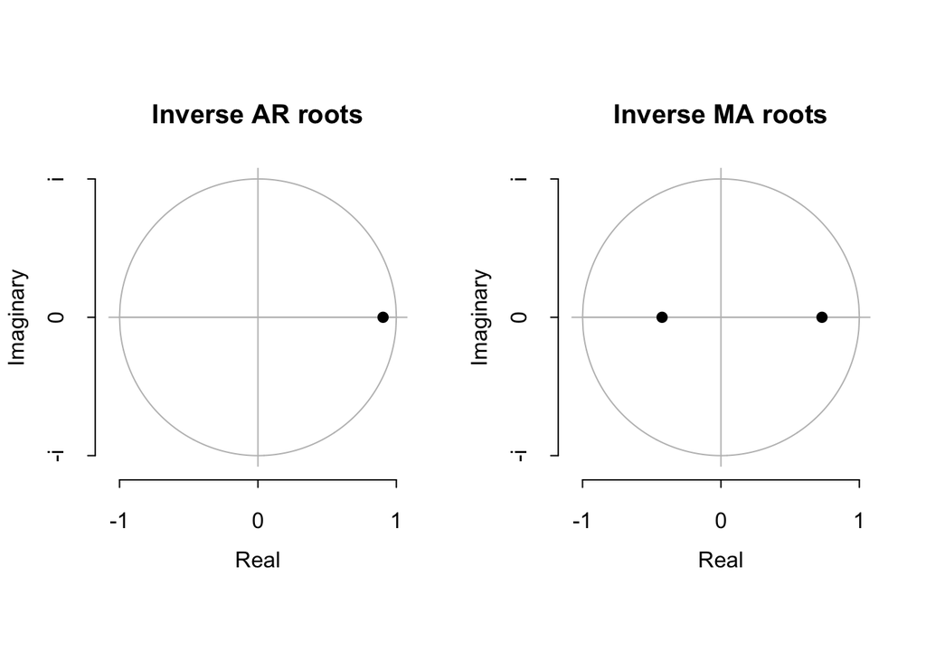

      ```r
      library(forecast)
      dt <- read.csv("BAB3mth.csv")
      Y <- ts(dt$BAB3, start=c(2010,1), end=c(2025,6), frequency=12)
      DY <- window(diff(Y), end=c(2024,6))
      ARIMA112 <- Arima(DY, order=c(1,0,2))
      plot(ARIMA112)
      ```

   2. The estimated coefficients are:

      ```r
      print(round(ARIMA112$coef,4))
      ```

      ```
            ar1       ma1       ma2 intercept
         0.9038   -0.3046   -0.3105    0.0040
      ```

      Thus $\widehat{\phi}_1 =0.9038$, $\widehat{\theta}_1 =-0.3046$, $\widehat{\theta}_2 =-0.3105$.  
      The AR model has order 1, so the inverted root is simply $0.9038$.  
      The MA model has order 2, so we specify the estimated lag polynomial  
      $\qquad\qquad 1 -0.3046 L -0.3105 L^2$  
      for the `polyroot` command:

      ```r
      MA2poly <- c(1,ARIMA112$coef[c("ma1", "ma2")])
      MA2invroots <- 1/polyroot(MA2poly)
      print(round(MA2invroots,4))
      ```

      ```
      [1]  0.7300+0i -0.4254+0i
      ```

      These are the roots we see plotted in part (a). The inverted roots are all inside of the unit circle. However the AR inverted root in particular is not far from the unit circle, i.e. quite close to 1. One of the MA roots is also quite large. Nevertheless there is not conclusive evidence of non-stationarity or non-invertibility here, and recall we already did ADF tests to choose the single difference being employed here. Notice again that for lag polynomials greater than order 1 the coefficients themselves ($\theta_1,\theta_2$) provide no insight into the inverted roots and hence invertibility (or stationarity for AR models).
4. 1. Code:

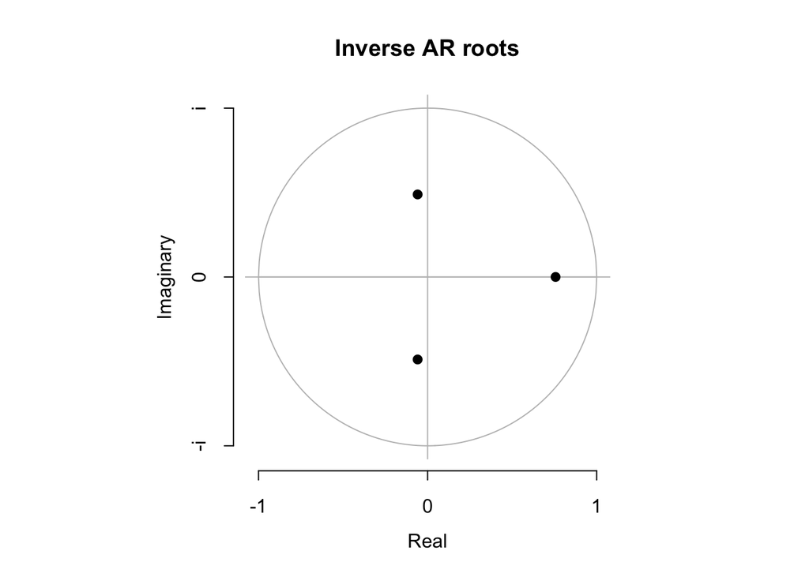

      ```r
      ARIMA310 <- Arima(DY, order=c(3,0,0))
      plot(ARIMA310)
      ```

   2. The estimated coefficients are:

      ```r
      print(round(ARIMA310$coef,4))
      ```

      ```
            ar1       ar2       ar3 intercept
         0.6387   -0.1530    0.1835    0.0018
      ```

      ```r
      AR3poly <- c(1,-ARIMA310$coef[c("ar1", "ar2", "ar3")])
      AR3invroots <- 1/polyroot(AR3poly)
      print(round(AR3invroots,4))
      ```

      ```
      [1]  0.7569+0.0000i -0.0591-0.4888i -0.0591+0.4888i
      ```

      ```r
      print(round(abs(AR3invroots),4))
      ```

      ```
      [1] 0.7569 0.4923 0.4923
      ```